# Who Lives At the Bonneville Salt Flats?

**Publications related to this work:**  
McGonigle, J.M., Bernau, J.A., Bowen, B.B., Brazelton W.J., 2021. Metabolic Potential of Microbial Communities in the Hypersaline Sediments of the Bonneville Salt Flats, *in review*  
McGonigle, J.M., Bernau, J.A., Bowen, B.B., Brazelton W.J., 2019. Robust Archaeal and Bacterial Communities Inhabit Shallow Subsurface Sediments of the Bonneville Salt Flats, mSphere 4:4 e00378-19

**Data Used:**  
Data is publicly available under: https://www.ncbi.nlm.nih.gov/bioproject/PRJNA522308

*A note on the data:*  
Metagenomic data contains genetic information of all cells and free DNA in the enviornmental sample. It represents a total community view. The abundance data used here is represenative of the entire microbial community. The MAGs (or bins) are sequences that are computationally pulled from the bulk data that have enough relation to each other to represent individual species genomes. These programs use methods like k-means clustering and genomic information such as GC-content and abundance to group related sequences together. Therefore the MAGs can give us a species-level look at the data, while the metagenomes give us a total-population-level look at it.

### Exploring Abundance of Microbial Metabolisms Across the BSF

Read mapping produced values for fragments per kilobase (FPK) for each gene. There are many ways to normalize abundance data, a good review can be found here: https://www.rna-seqblog.com/rpkm-fpkm-and-tpm-clearly-explained/. I normalize for gene length and sequencing depth to compare abundance of interesting genes across samples. This means the FPK needs to be converted to FPM (fragments per kilobase million), also known as TPM with RNA-Seq data.

#### Step 1: Data Wrangling FPK to FPKM

Convert FPK values to FPM/TPM, add more gene infomation by combining with KEGG reference list, save outputs for plotting

```r
## Load library ##
library("tidyverse")

## Load dataframes ##
samples.fpk <- read_csv("data/samples.fpk.csv")
KeggIdsOfInterest <- read_csv("data/KeggIdsOfInterest.csv")

## Change Entry to KEGG_ID so col names match
KeggIdsOfInterest <-  KeggIdsOfInterest %>%
  rename('KEGG_ID'= Entry)

## Change colnames samples.fpk, make new df because that kept row1 as sample names
names(samples.fpk) <- samples.fpk[1,]
dfSamples <- samples.fpk[2:6075,]

head(dfSamples)
head(KeggIdsOfInterest)
```

```r
#################### Convert FPK to TPM ########################################

## Process one column at a time. Function calculates TPM for each column.
ColumnTPM <- function(dataframe,i) {
  # Store column fpk counts into a list
  fpkList <- dataframe[1:nrow(dataframe),i]
  # Calculate scaling factor for column/sample
  denom <- sum(as.numeric(dataframe[,i]))/1e6
  # Do maths and convert all fpk values to tpm
  colList <- do.call(c, lapply(fpkList, function(e){
    tpm <- as.numeric(e)/denom
    return(tpm)
  }))

    return(colList)

}

dfTPM <- do.call(data.frame, lapply(2:ncol(dfSamples), ColumnTPM, dataframe=dfSamples))

# Copy the column names from the original dataframe, add back the KEGG_ID column
colnames(dfTPM) <- colnames(dfSamples[,-1])

dfTPM <- cbind(dfTPM, dfSamples$KEGG_ID)
colnames(dfTPM)[17] <- 'KEGG_ID'
str(dfTPM)

############ Test Values are correct using random number generator #############
##1-17 for cols: 12, 2, 5, 9, 16
##1-6074 for rows: 5335, 287, 4927, 2869, 1449

dfTPM[,12][5335]
#0
dfTPM[,2][287]
#137.8652
dfTPM[,5][4927]
#693.3421
dfTPM[,9][2869]
#372.0757
dfTPM[,16][1449]
#3.235608

## +1 for col number in dfSamples as df[1]=Kegg IDS
denom1 <- sum(as.numeric(dfSamples[,13]))/1e6
denom2 <- sum(as.numeric(dfSamples[,3]))/1e6
denom3 <- sum(as.numeric(dfSamples[,6]))/1e6
denom4 <- sum(as.numeric(dfSamples[,10]))/1e6
denom5 <- sum(as.numeric(dfSamples[,17]))/1e6

as.numeric(dfSamples[,13][5335])/denom1
#0
as.numeric(dfSamples[,3][287])/denom2
#137.8652
as.numeric(dfSamples[,6][4927])/denom3
#693.3421
as.numeric(dfSamples[,10][2869])/denom4
#372.0757
as.numeric(dfSamples[,17][1449])/denom5
#3.235608


##Save TPM df as csv
write.csv(dfTPM, file = 'samples_tpm.csv')

# Filter to make dfKEGGofIntFPK with subset of fpk for interesting KEGG ids
keggs <- as.vector(KeggIdsOfInterest$KEGG_ID)

dfKEGGofIntFPK <- dfTPM %>%
  filter(KEGG_ID %in% keggs)

## Change column name of Kegg ID to match and merge dfs, so have fpk and gene info

dfINTMergedTPM <- merge(dfKEGGofIntFPK,KeggIdsOfInterest,by="KEGG_ID")
write.csv(dfINTMergedTPM, file = 'samples_INT_tpm.csv')

####### Pull out Sulfur, Carbon, and Nitrogen Genes to save in seperate .csv ###
### Sulfur Genes: SOX, aprAB, dsrAB
### Nitrogen Genes: Nap, Nir, Nor, Nos
### Carbon Genes: Aerobic CODH, RuBisCO, mcrABG, Anaerobic CODH/ACS

dfINTMergedTPM <- samples_INT_tpm[,2:22]
str(dfINTMergedTPM)

keggS <- c('K17222','K17223','K17224','K17225','K17226','K17227','K00394','K00395','K11180','K11181')

dfSulfur <- dfINTMergedTPM %>%
  filter(KEGG_ID %in% keggS)

keggD1 <- c('K02567','K00368','K15864','K04748','K04561','K02305','K02448','K02164','K00376','K04747',
            'K00362','K00363','K00374','K02568')

dfDenit1 <- dfINTMergedTPM %>%
  filter(KEGG_ID %in% keggD1)

keggD2 <- c('K02567',
            'K00368',
            'K15864',
            'K04748',
            'K04561',
            'K02305',
            'K02448',
            'K02164',
            'K00376')

dfDenit2 <- dfINTMergedTPM %>%
  filter(KEGG_ID %in% keggD2)

keggC <- c('K01601',
           'K01602',
           'K00399',
           'K00401',
           'K00402',
           'K00198',
           'K14138',
           'K00194',
           'K00197',
           'K00192',
           'K00193',
           'K03518',
           'K03519',
           'K03520')

dfCarbon <- dfINTMergedTPM %>%
  filter(KEGG_ID %in% keggC)

## Save dfs for plotting: dfSulfur, dfDenit1, dfDenit2, dfCarbon

write.csv(dfSulfur, file = 'dfSulfurTPM.csv')
write.csv(dfDenit1, file = 'dfDenit1TPM.csv')
write.csv(dfDenit2, file = 'dfDenit2TPM.csv')
write.csv(dfCarbon, file = 'dfCarbonTPM.csv')
```

#### Step 2: Make Overview Heatmap

This code will create a heatmap of genes involved in macronutrient (sulfur, carbon, nitrogen) cycling at the BSF. This image shows clear abundance patterns across metabolisms. This uses the dataframe 'dfINTMergedTPM' from above and a reference file with each sample's group listed.

```r
###################### TPM Heatmap #############################################

RuBisCO <- c('K01601', 'K01602')

anaCO <- c(
  'K00192',
  'K00193',
  'K00195',
  'K15023',
  'K00196',
  'K00197',
  'K00194',
  'K00198',
  'K14138')

aeroCO <- c('K03518', 'K03519', 'K03520')

Acetate <- c('K00925', 'K00625', 'K13788')

Meth <- c('K00399', 'K00401', 'K00402', 'K14083')

Denitrification <- c(
  'K00368',
  'K00376',
  'K04561',
  'K04748',
  'K02567',
  'K02568',
  'K02448',
  'K15864',
  'K00370',
  'K00371',
  'K00374')

N2 <- c('K02586', 'K02588', 'K02591')

Dsr <- c('K11180','K11181')

SQR <- c('K17218')

Sox <- c(
  'K17222',
  'K17223',
  'K17224',
  'K17225',
  'K17226',
  'K17227')

All <- c(Sox, SQR, Dsr, N2, Denitrification, Meth, Acetate, aeroCO, anaCO, RuBisCO)

head(dfINTMergedTPM)

overviewTPM <- dfINTMergedTPM %>%
  filter(KEGG_ID %in%  All)

overviewTPM <- overviewTPM[,1:18]

for (row in 1:nrow(overviewTPM)) {
  if (overviewTPM$KEGG_ID[row] %in% Sox) {
    overviewTPM$Definition[row] <- 'SOX System'
  } else if (overviewTPM$KEGG_ID[row] %in% SQR) {
    overviewTPM$Definition[row] <- 'Sulfide Oxidation'
  } else if  (overviewTPM$KEGG_ID[row] %in% Dsr) {
    overviewTPM$Definition[row] <- 'Sulfate Reduction'
  } else if  (overviewTPM$KEGG_ID[row] %in% N2) {
    overviewTPM$Definition[row] <- 'N2 Fixation'
  } else if  (overviewTPM$KEGG_ID[row] %in% Denitrification) {
    overviewTPM$Definition[row] <- 'Denitrification'
  } else if  (overviewTPM$KEGG_ID[row] %in% Meth) {
    overviewTPM$Definition[row] <- 'Methanogenesis'
  } else if  (overviewTPM$KEGG_ID[row] %in% Acetate) {
    overviewTPM$Definition[row] <- 'Acetate Formation'
  } else if  (overviewTPM$KEGG_ID[row] %in% aeroCO) {
    overviewTPM$Definition[row] <- 'Aerobic CODH'
  } else if  (overviewTPM$KEGG_ID[row] %in% anaCO) {
    overviewTPM$Definition[row] <- 'Anaerobic CODH'
  } else if  (overviewTPM$KEGG_ID[row] %in% RuBisCO) {
    overviewTPM$Definition[row] <- 'RuBisCO'
  } else {
    print("Something is wrong")
  }}

overviewTPM <- overviewTPM %>%
  mutate(Definition = fct_relevel(Definition,
                               'Sulfide Oxidation',
                               'Sulfate Reduction',
                               'SOX System',
                               'Aerobic CODH',
                               'Anaerobic CODH',
                               'Acetate Formation',
                               'RuBisCO',
                               'Denitrification',
                               'N2 Fixation',
                               'Methanogenesis'))


overviewTPM

overviewTPM[9,]$Name <- 'narG/nxrA'
overviewTPM[10,]$Name <- 'narH/nxrB'
overviewTPM[11,]$Name <- 'narI'
overviewTPM[33,]$Name <- 'pta1'
overviewTPM[6,]$Name <- 'acsC'
overviewTPM[7,]$Name <- 'acsA'
overviewTPM[3,]$Name <- 'acsD'

rownames(overviewTPM)
rownames(overviewTPM) <- c(overviewTPM$Name)

overviewTPM$Name

overviewMatrix <- as.matrix(overviewTPM[,2:17])

overviewScaledMatrix <- scale(overviewMatrix)

#### sample_groups is two cols: Sample and Group
groups.df <- as.data.frame(sample_groups[,2], row.names = sample_groups$Sample)

groups.df

groups.t.df <- t(groups.df)

groups.t.df[1,1:16]

Heatmap(overviewScaledMatrix,
        row_split = overviewTPM$Definition,
        column_split = groups.t.df[1,1:16],
        row_names_gp = gpar(fontsize = 11))

################################################################################
```

**Plot was made in R and then edited to this final version in Illustrator**

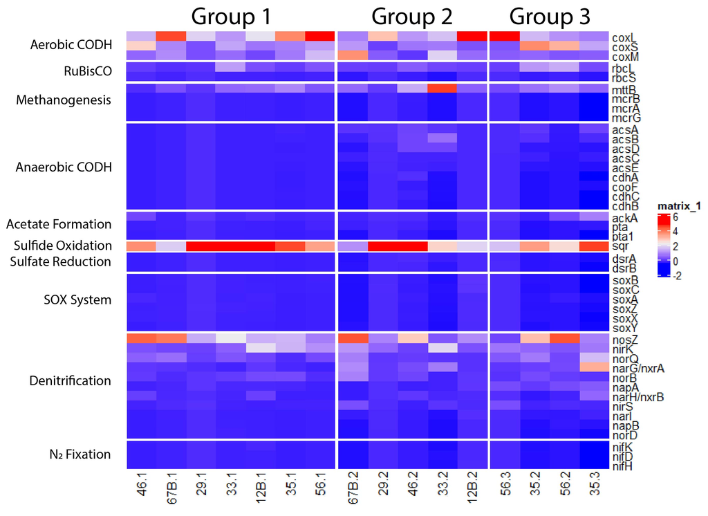

```r
library("IRdisplay")
display_png(file="SmallJPGs/FigureS2.jpg")
```

#### Step 3: Make Abundance Bubble Plots for Each Macronutrient

I stacked TPM sample matrix in excel so that tpm and sample are columns in melted format instead. Re-load dataframes and libraries into R. Dataframes to plot from above data wrangling: dfSulfurTPM, dfNitTPM (combined Denit1 and Denit2. renamed), dfCarbonTPM

```r
library(ComplexHeatmap)
library(tidyverse)

dfCarbonTPM <- read_csv('dfCarbonTPM.csv')
dfNitTPM <- read_csv('dfNitTPM.csv')
dfSulfurTPM <- read_csv('dfSulfurTPM.csv')
```

```r
########################## Write BubblePlot() Functions ##################################
SampleNitPathBubblePlot <- function(dataframe){
  # return a bubble style plot for a gene abundance per Sample and Sample Grouping
  # Inputs: dataframe = raw data frame of gene abundance data formatted with colnames: Name, Sample, Group, tpm

  cols <- c('Name', 'Group')
  dataframe[cols] <- lapply(dataframe[cols], factor)

  #Order x-axis samples, remove points for samples with zeros
  SamplePlot <- dataframe[which(dataframe$tpm>0),] %>%
    mutate(Sample = fct_relevel(Sample,
                                "D35.1","D33.1","D29.1","D56.1","D46.1","D12B.1","D67B.1",
                                "D33.2","D29.2","D46.2","D12B.2","D67B.2",
                                "D35.2","D35.3","D56.2","D56.3"),
           Name = fct_relevel(Name,
                              "napA","napB","narI","narG","narH", "nirS", "nirK", "norB","norC","norD",
                              "norQ", "nosZ", "nirB","nirD","nrfA","nrfH")) %>%
    ggplot(aes(x=Sample, y=Name))

  ##Plot ggplot2 object, size bubbles is tpm, color is gene
  BubblePlot <- SamplePlot +
    geom_count(aes(size=tpm, color=Pathway)) +
    theme(panel.grid.major = element_blank(), panel.grid.minor = element_blank(),
          panel.background = element_blank(), axis.line = element_line(colour = "black")) +
    scale_size(range = c(1,15))

  return(BubblePlot)

}

SampleCPathBubblePlot <- function(dataframe){
  # return a bubble style plot for a gene abundance per Sample and Sample Grouping
  # Inputs: dataframe = raw data frame of gene abundance data formatted with colnames: Name, Sample, Group, tpm

  cols <- c('Name', 'Group')
  dataframe[cols] <- lapply(dataframe[cols], factor)

  ##Make $Pathway column

  rbcList <- c('rbcS','rbcL')
  methList <- c('mcrA','mcrB','mcrG')
  aeroCODHList <- c('coxS','coxM','coxL')
  anaeroCODHList <- c('cooS_acsA','cdhE_acsC','cdhD_acsD','cdhC','cdhA','acsB')

  for (row in 1:nrow(dataframe)) {
    if (dataframe$Name[row] %in% rbcList) {
      dataframe$Pathway[row] <- 'RuBiSCO'
    } else if (dataframe$Name[row] %in% methList) {
      dataframe$Pathway[row] <- 'Methanogenesis'
    } else if  (dataframe$Name[row] %in% aeroCODHList) {
      dataframe$Pathway[row] <- 'AerobicCODH'
    } else if  (dataframe$Name[row] %in% anaeroCODHList) {
      dataframe$Pathway[row] <- 'AnaerobicCODH'
    } else {
      print("Something is wrong")
    }}

  #Order x-axis samples, remove points for samples with zeros
  SamplePlot <- dataframe[which(dataframe$tpm>0),] %>%
    mutate(Sample = fct_relevel(Sample,
                                "D35.1","D33.1","D29.1","D56.1","D46.1","D12B.1","D67B.1",
                                "D33.2","D29.2","D46.2","D12B.2","D67B.2",
                                "D35.2","D35.3","D56.2","D56.3")) %>%
    ggplot(aes(x=Sample, y=Name))

  ##Plot ggplot2 object, size bubbles is tpm, color is gene
  BubblePlot <- SamplePlot +
    geom_count(aes(size=tpm, color=Pathway)) +
    theme(panel.grid.major = element_blank(), panel.grid.minor = element_blank(),
          panel.background = element_blank(), axis.line = element_line(colour = "black")) +
    scale_size(range = c(1,15))

  return(BubblePlot)

}

SampleRedoxPathBubblePlot <- function(dataframe){
  # return a bubble style plot for a gene abundance per Sample and Sample Grouping
  # Inputs: dataframe = raw data frame of gene abundance data formatted with colnames: Name, Sample, Group, tpm

  cols <- c('Name', 'Group')
  dataframe[cols] <- lapply(dataframe[cols], factor)

  ##Make $Pathway column

  RedoxList <- c('dsrB','dsrA','aprA','aprB')
  dataframe$Redox <- ifelse(dataframe$Name %in% RedoxList, 'Reduction', 'Oxidation')

  #Order x-axis samples, remove points for samples with zeros
  SamplePlot <- dataframe[which(dataframe$tpm>0),] %>%
    mutate(Sample = fct_relevel(Sample,
                                "D35.1","D33.1","D29.1","D56.1","D46.1","D12B.1","D67B.1",
                                "D33.2","D29.2","D46.2","D12B.2","D67B.2",
                                "D35.2","D35.3","D56.2","D56.3")) %>%
    ggplot(aes(x=Sample, y=Name))

  ##Plot ggplot2 object, size bubbles is tpm, color is gene
  BubblePlot <- SamplePlot +
    geom_count(aes(size=tpm, color=Redox)) +
    theme(panel.grid.major = element_blank(), panel.grid.minor = element_blank(),
          panel.background = element_blank(), axis.line = element_line(colour = "black")) +
    scale_size(range = c(1,15))

  return(BubblePlot)

}

SampleCPathBubblePlot(dfCarbonTPM)
SampleRedoxPathBubblePlot(dfSulfurTPM)

##### Remove norE from Nitrogen Plots for better readibility #####
dfNitTPM_new <- dfNitTPM %>%
  filter(Name != 'norE')

SampleNitPathBubblePlot(dfNitTPM_new)
```

**Plots were made in R and then edited to these final versions with Illustrator**

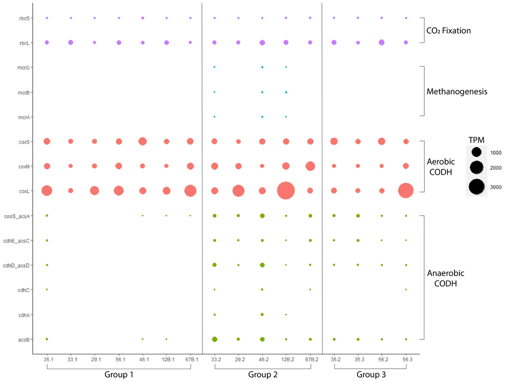

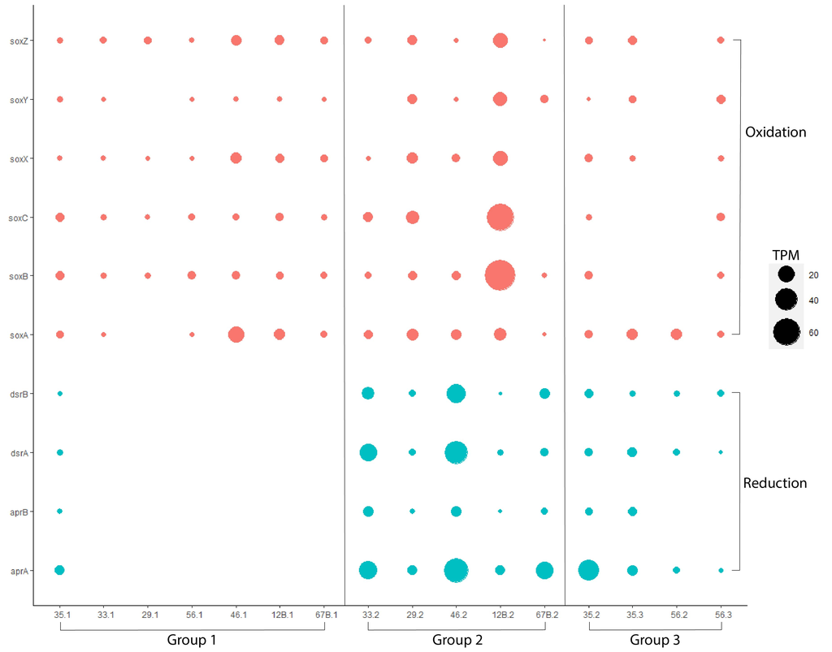

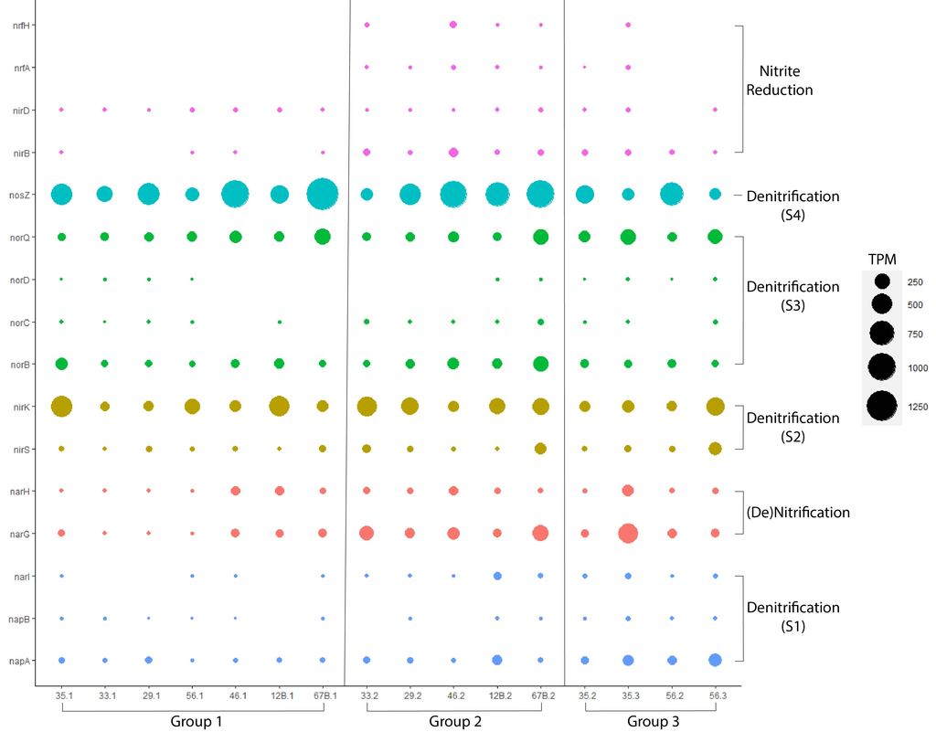

```r
display_png(file="SmallJPGs/Figure2.jpg")
display_png(file="SmallJPGs/Figure6.jpg")
display_png(file="SmallJPGs/Figure3.jpg")
```

#### Step 4: Make MAG plot for Each Pathway

Switching from the community centric view over to the species-level view. This plot will show which pathways and gene combinations are complete in each MAG

```r
#################### MAG "geom_tile()" Plot ####################################

#load data as MAG_Mods
head(MAG_Mods)

## row 505+ are empty
MAG_Mods <- MAG_Mods[1:504,]

#Make ggplot Object

for (row in 1:nrow(MAG_Mods)) {
  if (MAG_Mods$Completeness[row] == 'complete') {
    MAG_Mods$Value[row] <- 1
  } else if (MAG_Mods$Completeness[row] == 'partial') {
    MAG_Mods$Value[row] <- 0.5
  } else if  (MAG_Mods$Completeness[row] == 'none') {
    MAG_Mods$Value[row] <- 0
  } else {
    print("Something is wrong")
  }}

MAG_Mods$Value <- factor(MAG_Mods$Value)
MAG_Mods$Pathway <- factor(MAG_Mods$Pathway)


MAG_Mods <- MAG_Mods %>%
  mutate(Completeness = fct_relevel(Completeness, 'complete', 'partial', 'none'))

MAGPlot <- MAG_Mods %>%
  mutate(Pathway = fct_relevel(Pathway,
                            'Complex I',
                            'Cyt. c Oxidase',
                            'TCA cycle, 1st C Oxidation',
                            'TCA cycle, 2nd C Oxidation',
                            'RuBisCO',
                            'Aerobic CODH',
                            'Anaerobic CODH/ACS (acsACD)',
                            'Acetyl-CoA Synthetase (acs)',
                            'Acetyl-CoA Synthase (acsB)',
                            'Acetate Kinase',
                            'Phosphate Acetyltransferase',
                            'Sox System (soxABCXYZ)',
                            'Sulfide:quinone Reductase (SQR)',
                            'Nitrate Reductase (napAB or narGHI)',
                            'Nitrite Reductase (nirK)',
                            'Nitric Oxide Reductase (norBQ)',
                            'Nitrous Oxide Reductase (nosZ)',
                            'Nitrite Reductase (nirBD or nrfAH)')) %>%
  ggplot(aes(Bin, Pathway, fill=Value))



cols <- c("none" = "grey93", "partial" = "grey63", "complete" = "black")

MAGPlot +
  geom_tile(aes(fill=Completeness), color = 'white') +
  scale_y_discrete(limits=rev) +
  scale_fill_manual(values = cols) +
  ggtitle("Metabolic Pathways and Complexes in BSF MAGs") +
  labs(fill = element_blank()) +
  theme(panel.grid.major = element_blank(),
        panel.grid.minor = element_blank(),
        panel.background = element_blank(),
        axis.text.x = element_text(angle = 90, vjust = 0.35, size = 12),
        axis.title.x = element_blank(),
        axis.text.y = element_text(size = 12),
        axis.title.y = element_blank(),
        plot.title = element_text(size=21, face="bold", hjust = 0.5))
################################################################################
```

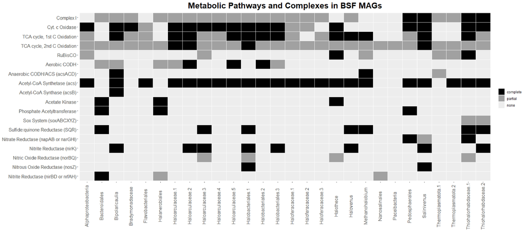

```r
display_png(file="SmallJPGs/Figure1.jpg")
```